# 3. Logistic Regression

Chapter 3

Dennis Schroers, Institute of Finance and Statistics, University of Bonn

## **Chapters**

- 1. Probability Basics
  - 1.1 Probability Distributions
  - 1.2 Expected Value and Moments
  - 1.3 LLN and CLT
  - 1.4 Monte Carlo Simulation
  - 1.5 Estimation and Inference
  - Exercises
- 2. Linear Regression
  - 2.1 Simple Linear Regression - OLS estimation and Inference under Normality
  - 2.2 Multivariate Linear Regression - OLS and Inference under Normality
  - 2.3 Assumptions, Diagnostics and Troubleshooting
  - 2.4 Model Selection
  - Exercises
- **3. Logistic Regression**
  - 3.1 Logistic Regression with a Single Regressor
  - 3.2 Logistic Regression with Several Regressors
  - 3.3 Estimation and Inference
  - 3.4 Diagnostics and Troubleshooting
  - 3.5 Model Selection
  - Exercises

## **References**

- Zuur, Ieno, Smith (2007), *Analyzing Ecological Data*, Springer.
- Gelman, Hill, Vehtari (2020), “Regression and other stories”, Cambridge University Press.
- Hosmer, Lemeshow, Sturdivant (2020), “Applied Logistic Regression”, Wiley.

# Logistic Regression with a Single Regressor

## Example: *Solea solea* versus salinity

Consider the dataset on the occurence of *Solea solea* (a sole) in the Tagus estuary in Portugal, cf. Cabral et al. (2007).

The data come from a sampling study in which *S. solea* abundance and environmental conditions were recorded at several times and locations in the estuary.

For our analysis, we focus on

- whether *S. solea* was **present or absent**, and
- the measured level of **salinity**.

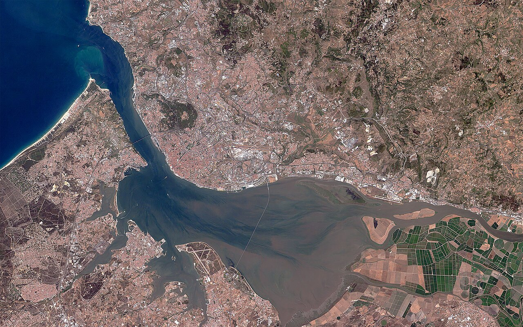

Satellite image: Axelspace Corporation, Wikimedia Commons, [CC BY-SA 4.0](https://creativecommons.org/licenses/by-sa/4.0/)

**Main Question:** How does the probability of observing *S. solea* change with salinity?

## Modeling a binary response

We observe $n (= 65)$ binary outcomes $y_1,\ldots,y_n$, where

$$y_i =
\begin{cases}
0 & \text{sole absent},\\
1 & \text{sole present}.
\end{cases}$$
and corresponding salinity values $x_1,\ldots,x_n$ which we treat as fixed.

Each observed outcome $y_i$ is regarded as a realization of a Bernoulli random variable where we model the parameter as a function of the covariate, i.e.:

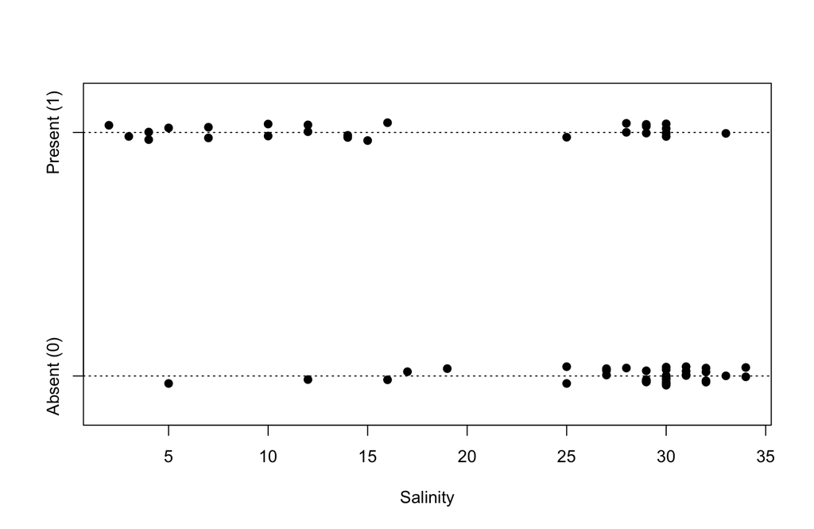

Points are slightly jittered vertically to make overlapping observations visible. Repeated salinity values do not imply repeated measurements at the same place and time. Salinity is recorded on a relatively coarse integer scale, so distinct samples can share the same recorded salinity value.

$$Y_i \sim \operatorname{Bernoulli}(p_i),\qquad s.t.\qquad
p_i
=
\mathbb P(Y_i=1)
=
\mathbb E[Y_i] = p(x_i) \qquad i=1,\ldots,n.
.$$

**How to model $p(\cdot)$?**

## Linearly Regressing the Probability?

We might first try linear regression and model

$$p(x)=\beta_0+\beta_1 x.$$

But whereas a linear predictor can take **any real value**, probabilities must satisfy

$$0\leq p(x)\leq 1,$$

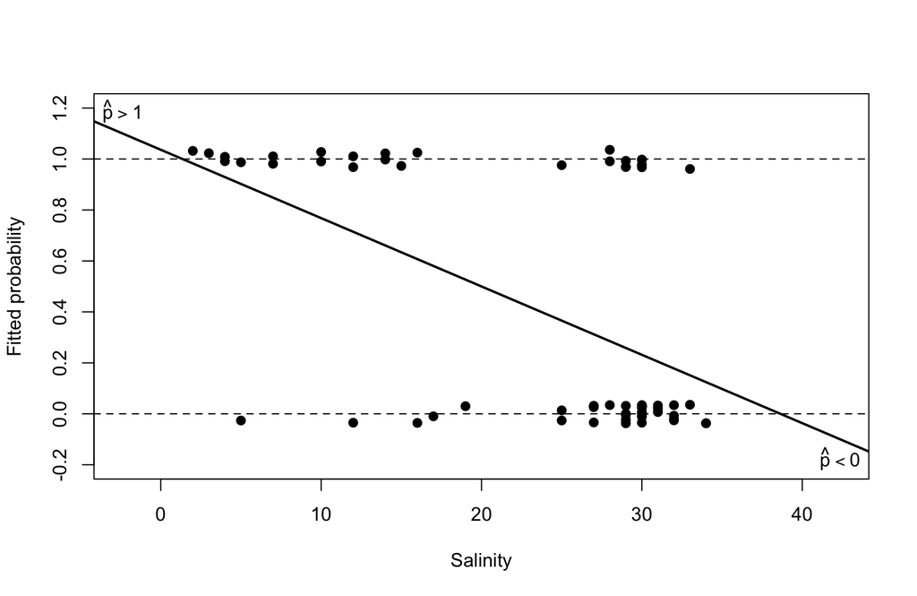

**Idea:** Find a transformation $g$ on $(0,1)$ such that $g(p)$ can take any real value and then model linearly (and then transform back).

$$g(p(x))=\beta_0+\beta_1 x$$

## **The Odds**

When we assume that $0<p(x)<1$, a first reasonable and interpretable transformation of a probability is

$$O(x) = \frac{p(x)}{1-p(x)} >0.$$

These are the **odds** of the event occurring.

- If $O(x) > 1$, the event is **more likely to occur than not**.
  - $O(x) = 2$ means that the event is **twice as likely to occur as not**.
- If $O(x) = 1$, the event is **equally likely to occur or not**.
- If $0 < O(x) < 1$, the event is **less likely to occur than not**.
  - $O(x) = 0.5$ means that the event is **half as likely to occur as not**.

## Log odds

The odds can take any positive value, but they **cannot take negative values**, so modelling the odds directly with a linear regression is not appropriate.

Since $O(x)>0$, a simple **logarithmic transformation** accounts for the nonnegativity of the odds:

$$\log(O(x))= \log \left(\frac {p(x)}{1-p(x)}\right)$$

## Logistic Regression

In logistic regression, the log odds are modelled as a linear function of the covariates:

$$\log(O(x))=\log\left(\frac{p(x)}{1-p(x)}\right)= \beta_0+\beta_1 x$$

$$\Leftrightarrow p(x) =\frac{\exp(\beta_0+ \beta_1 x)}{1+\exp(\beta_0+ \beta_1 x)} \in (0,1)$$

for real coefficients $\beta_0,\beta_1 \in \mathbb R$.

The inverse of the transformation $g$ (i.e. transformation to the log odds)
$$g^{-1}(x)= \frac{\exp(x)}{1+\exp(x)}$$
is called *logistic function*, hence the name.

## Logistic Regression (ctn.)

The parameter $\beta_0$ shifts the logistic curve horizontally, while $\beta_1$ determines its steepness and whether the curve is increasing ($\beta_1>0$) or decreasing ($\beta_1<0$):

**β<sub>0</sub>** = -5.00

**β<sub>1</sub>** = 0.20

g(x) = -5.00 + 0.20x

[interactive chart not shown]

## Logistic Regression (ctn.)

**Warning**

Note that the coefficient $\beta_1$ **does not correspond to a one-unit change in $Y$** for a one-unit change in the respective covariate.

Instead, consider the odds

$$\frac{O(x+1)}{O(x)}
=
\frac{\exp\left(
\beta_0+\beta_1 (x+1)
\right)}{\exp\left(
\beta_0+\beta_1 x
\right)}
=
\exp(\beta_1)$$

So a one-unit increase in $x$ multiplies the odds by $\exp(\beta_1)$. Thus:

- $\beta_1=0 ;\Rightarrow; \exp(\beta_1)=1$: the odds do not change.
- $\beta_1>0 ;\Rightarrow; \exp(\beta_1)>1$: the odds increase.
- $\beta_1<0 ;\Rightarrow; \exp(\beta_1)<1$: the odds decrease.

## Logistic Regression in R

In R, logistic regression is fitted with `glm()` using a **binomial family**:

```r
solea <- read.table("data/Solea.txt", header = TRUE)

fit <- glm(Solea_solea ~ salinity, data = solea, family = binomial)

summary(fit)
```

```
Call:
glm(formula = Solea_solea ~ salinity, family = binomial, data = solea)

Coefficients:
            Estimate Std. Error z value Pr(>|z|)
(Intercept)  2.66071    0.90167   2.951 0.003169 **
salinity    -0.12985    0.03494  -3.716 0.000202 ***
---
Signif. codes:  0 '***' 0.001 '**' 0.01 '*' 0.05 '.' 0.1 ' ' 1

(Dispersion parameter for binomial family taken to be 1)

    Null deviance: 87.492  on 64  degrees of freedom
Residual deviance: 68.560  on 63  degrees of freedom
AIC: 72.56

Number of Fisher Scoring iterations: 4
```

## Logistic Regression in R (ctn.)

**Interpretation:**

- The negative estimated $\beta_1$ suggests, that the probability of observing *S. Solea* increases when Salinity decreases.
- The p-value of $0.000202$ indicates that the hypothesis that there is no association of Salinity with the recording of *S.Solea* can be rejected at the $0.1\%$ significance level.

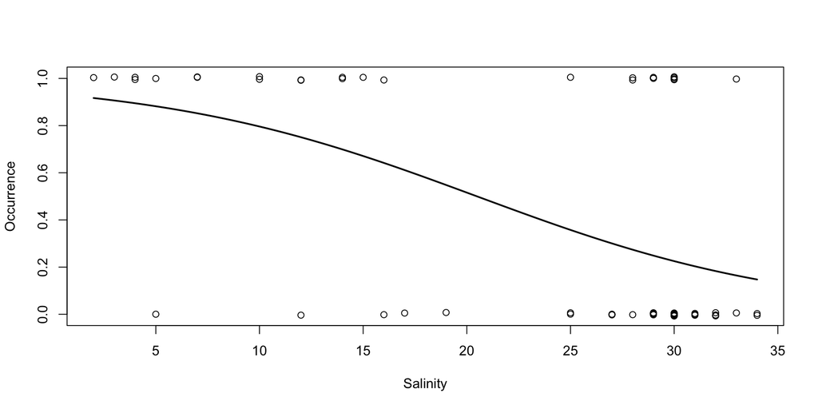

## Exercise

Fit a logistic regression model via the `glm()`-function for the occurrence of *S. solea*, using *temperature* instead of *salinity* as the explanatory variable. Answer the following questions:

- does the probability of the occurence of *S.Solea* tend to increase or descrease with temperature?
- Is the coefficient $\beta_1$ corresponding to *temperature* significantly different from $0$?
- Treat the fitted logistic regression model as the data-generating model, i.e. set $\beta_0=\widehat\beta_0$ and $\beta_1=\widehat\beta_1$. Keeping the $65$ observed temperature values fixed, simulate a new binary response for each observation from the fitted model and refit the logistic regression to obtain a new estimate $\widehat\beta_1^*$.

  Repeat this procedure $K=10000$ times to obtain

  $$\widehat\beta_{1,1}^*,\ldots,\widehat\beta_{1,K}^*.$$

  Plot the estimated density of the simulated estimates using the `density()`function and compare it with the density of the best-fitting normal distribution. Does a normal distribution appear to provide a reasonable approximation to the sampling distribution of $\widehat\beta_1$?

# Logistic Regression with a Multiple Regressors

# Estimation and Inference

- Maximum Likelihood Estimation
- Assumptions and complications: Nonlinear log odds, conditional independence, Identification and separation and exact collinearity
- Wald test, likelihood ratios and Deviance

# Troubleshooting and diagnostics

- exact collinearity
- Separation / sparse data
- Numerical convergence
- Influence

# Model specification and comparison

- confounders
- Interactions
- Purposeful Model selection
- Goodness of Fit (Hosmer-Lemeshow test)
- Cross-validation (Deviance and Brier)
- AIC

# Exercises

# References

Cabral, Henrique, Alain F. Zuur, Elena N. Ieno, and Graham M. Smith. 2007. “Analysing Presence and Absence Data for Flatfish Distribution in the Tagus Estuary, Portugal.” In *Analyzing Ecological Data*. Springer. https://doi.org/10.1007/978-0-387-45972-1_21.